# Biostat 203B Homework 5

Due Mar 22 @ 11:59PM

Author

Ruidong Zhang 206294444

## Predicting ICU duration

Using the ICU cohort `mimiciv_icu_cohort.rds` you built in Homework 4, develop at least three machine learning approaches (logistic regression with enet regularization, random forest, boosting, SVM, MLP, etc) plus a model stacking approach for predicting whether a patient’s ICU stay will be longer than 2 days. You should use the `los_long` variable as the outcome. You algorithms can use patient demographic information (gender, age at ICU `intime`, marital status, race), ICU admission information (first care unit), the last lab measurements before the ICU stay, and first vital measurements during ICU stay as features. You are welcome to use any feature engineering techniques you think are appropriate; but make sure to not use features that are not available at an ICU stay’s `intime`. For instance, `last_careunit` cannot be used in your algorithms.

```r
# Load libraries
library(dials)
library(rpart.plot)
library(vip)
library(tidymodels)
library(tidyverse)
library(readr)
library(GGally)
library(gtsummary)
library(keras)
library(reticulate)
library(ranger)
library(stacks)
library(kernlab)
library(xgboost)
library(dplyr)
library(tune)
library(parallel)
library(doParallel)
```

## 1. Data preprocessing and feature engineering.

```r
mimic_icu_cohort <- readRDS("mimiciv_shiny/mimic_icu_cohort.rds")
mimic_icu_cohort
```

```
# A tibble: 73,181 × 33
   subject_id  hadm_id  stay_id first_careunit last_careunit intime
        <int>    <int>    <int> <fct>          <fct>         <dttm>
 1   10287015 27614346 37924967 Other          Other         2170-02-09 23:47:23
 2   10765746 28051876 35281441 Other          Other         2156-01-07 09:10:00
 3   11997599 25252737 33179530 Other          Other         2158-01-16 12:31:00
 4   12854615 29306595 38198377 Other          Other         2189-08-22 22:07:51
 5   15260995 26845133 35739203 Other          Other         2138-11-03 23:07:44
 6   15585720 29638262 36722914 Other          Other         2134-05-18 23:27:00
 7   16962213 24281725 38225138 Other          Other         2167-08-18 23:53:00
 8   17326715 23718725 38743306 Other          Other         2166-08-09 02:41:00
 9   17491268 21843002 31844112 Other          Other         2154-02-13 18:11:20
10   18872730 23566640 32829081 Other          Other         2167-10-09 21:10:57
# ℹ 73,171 more rows
# ℹ 27 more variables: los <dbl>, gender <chr>, dod <date>, dischtime <dttm>,
#   admission_type <fct>, admission_location <fct>, discharge_location <fct>,
#   insurance <chr>, language <chr>, marital_status <chr>, race <fct>,
#   hospital_expire_flag <int>, age_intime <int>, hematocrit <dbl>,
#   potassium <dbl>, sodium <dbl>, wbc <dbl>, bicarbonate <dbl>,
#   chloride <dbl>, creatinine <dbl>, glucose <dbl>, …
```

```r
mimic_icu_cohort <- mimic_icu_cohort |>
  mutate(intime = hour(intime)) |>
  mutate(los_long = as.factor(los_long))

# sort
mimic_icu_cohort <- mimic_icu_cohort |>
  select(los_long, subject_id, hadm_id, stay_id, gender,
         age_intime, marital_status,
         race, first_careunit, admission_type, creatinine,
         wbc, glucose, chloride, hematocrit,
         potassium, bicarbonate, sodium, temperature_fahrenheit,
         respiratory_rate, non_invasive_blood_pressure_diastolic,
         non_invasive_blood_pressure_systolic, heart_rate) %>%
  mutate(los_long = as.factor(los_long)) %>%
print(width = Inf)
```

```
# A tibble: 73,181 × 23
   los_long subject_id  hadm_id  stay_id gender age_intime marital_status race
   <fct>         <int>    <int>    <int> <chr>       <int> <chr>          <fct>
 1 FALSE      10287015 27614346 37924967 M              68 MARRIED        Other
 2 FALSE      10765746 28051876 35281441 M              76 MARRIED        BLACK
 3 TRUE       11997599 25252737 33179530 F              91 WIDOWED        WHITE
 4 TRUE       12854615 29306595 38198377 M              81 MARRIED        BLACK
 5 TRUE       15260995 26845133 35739203 F              64 MARRIED        WHITE
 6 TRUE       15585720 29638262 36722914 F              74 MARRIED        WHITE
 7 FALSE      16962213 24281725 38225138 F              60 MARRIED        WHITE
 8 TRUE       17326715 23718725 38743306 F              65 DIVORCED       WHITE
 9 FALSE      17491268 21843002 31844112 M              67 MARRIED        WHITE
10 FALSE      18872730 23566640 32829081 F              66 <NA>           Other
   first_careunit admission_type              creatinine   wbc glucose chloride
   <fct>          <fct>                            <dbl> <dbl>   <dbl>    <dbl>
```

[output cut: 47 more lines]

## 2. Partition, sort and use the seed `203` for the initial data split.

```r
mimic_icu_cohort %>%
  arrange(subject_id, hadm_id, stay_id)
```

```
# A tibble: 73,181 × 23
   los_long subject_id  hadm_id  stay_id gender age_intime marital_status race
   <fct>         <int>    <int>    <int> <chr>       <int> <chr>          <fct>
 1 FALSE      10000032 29079034 39553978 F              52 WIDOWED        WHITE
 2 FALSE      10000980 26913865 39765666 F              76 MARRIED        BLACK
 3 FALSE      10001217 24597018 37067082 F              55 MARRIED        WHITE
 4 FALSE      10001217 27703517 34592300 F              55 MARRIED        WHITE
 5 FALSE      10001725 25563031 31205490 F              46 MARRIED        WHITE
 6 TRUE       10001884 26184834 37510196 F              77 MARRIED        BLACK
 7 FALSE      10002013 23581541 39060235 F              57 SINGLE         Other
 8 FALSE      10002155 20345487 32358465 F              83 MARRIED        WHITE
 9 TRUE       10002155 23822395 33685454 F              81 MARRIED        WHITE
10 TRUE       10002155 28994087 31090461 F              82 MARRIED        WHITE
# ℹ 73,171 more rows
# ℹ 15 more variables: first_careunit <fct>, admission_type <fct>,
#   creatinine <dbl>, wbc <dbl>, glucose <dbl>, chloride <dbl>,
#   hematocrit <dbl>, potassium <dbl>, bicarbonate <dbl>, sodium <dbl>,
#   temperature_fahrenheit <dbl>, respiratory_rate <dbl>,
#   non_invasive_blood_pressure_diastolic <dbl>,
#   non_invasive_blood_pressure_systolic <dbl>, heart_rate <dbl>
```

```r
mimic_icu_cohort
```

```
# A tibble: 73,181 × 23
   los_long subject_id  hadm_id  stay_id gender age_intime marital_status race
   <fct>         <int>    <int>    <int> <chr>       <int> <chr>          <fct>
 1 FALSE      10287015 27614346 37924967 M              68 MARRIED        Other
 2 FALSE      10765746 28051876 35281441 M              76 MARRIED        BLACK
 3 TRUE       11997599 25252737 33179530 F              91 WIDOWED        WHITE
 4 TRUE       12854615 29306595 38198377 M              81 MARRIED        BLACK
 5 TRUE       15260995 26845133 35739203 F              64 MARRIED        WHITE
 6 TRUE       15585720 29638262 36722914 F              74 MARRIED        WHITE
 7 FALSE      16962213 24281725 38225138 F              60 MARRIED        WHITE
 8 TRUE       17326715 23718725 38743306 F              65 DIVORCED       WHITE
 9 FALSE      17491268 21843002 31844112 M              67 MARRIED        WHITE
10 FALSE      18872730 23566640 32829081 F              66 <NA>           Other
# ℹ 73,171 more rows
# ℹ 15 more variables: first_careunit <fct>, admission_type <fct>,
#   creatinine <dbl>, wbc <dbl>, glucose <dbl>, chloride <dbl>,
#   hematocrit <dbl>, potassium <dbl>, bicarbonate <dbl>, sodium <dbl>,
#   temperature_fahrenheit <dbl>, respiratory_rate <dbl>,
#   non_invasive_blood_pressure_diastolic <dbl>,
#   non_invasive_blood_pressure_systolic <dbl>, heart_rate <dbl>
```

```r
set.seed(203)

data_split <- initial_split(
  mimic_icu_cohort,
  # stratify by los_long
  strata = "los_long",
  prop = 0.5
  )

cohort_other <- training(data_split)
dim(cohort_other)
```

```
[1] 36590    23
```

```r
cohort_test <- testing(data_split)
dim(cohort_test)
```

```
[1] 36591    23
```

```r
# Define the recipe
log_recipe <- recipe(los_long ~ ., data = cohort_other) %>%
  step_rm(subject_id, hadm_id, stay_id) %>%
  step_impute_mean(creatinine, wbc, glucose,
         bicarbonate, sodium, chloride, potassium,
         hematocrit, temperature_fahrenheit,
         respiratory_rate, non_invasive_blood_pressure_diastolic,
         non_invasive_blood_pressure_systolic, heart_rate) %>%
  step_impute_mode(marital_status) %>%
  step_dummy(all_nominal_predictors()) %>%
  step_zv(all_numeric_predictors()) %>%
  step_normalize(all_numeric_predictors()) %>%
  print()
```

```
── Recipe ──────────────────────────────────────────────────────────────────────
```

```
── Inputs
```

```
Number of variables by role
```

```
outcome:    1
predictor: 22
```

```
── Operations
```

```
• Variables removed: subject_id, hadm_id, stay_id
```

```
• Mean imputation for: creatinine, wbc, glucose, bicarbonate, sodium, ...
```

```
• Mode imputation for: marital_status
```

```
• Dummy variables from: all_nominal_predictors()
```

```
• Zero variance filter on: all_numeric_predictors()
```

```
• Centering and scaling for: all_numeric_predictors()
```

```r
log_recipe
```

```
── Recipe ──────────────────────────────────────────────────────────────────────
```

```
── Inputs
```

```
Number of variables by role
```

```
outcome:    1
predictor: 22
```

```
── Operations
```

```
• Variables removed: subject_id, hadm_id, stay_id
```

```
• Mean imputation for: creatinine, wbc, glucose, bicarbonate, sodium, ...
```

```
• Mode imputation for: marital_status
```

```
• Dummy variables from: all_nominal_predictors()
```

```
• Zero variance filter on: all_numeric_predictors()
```

```
• Centering and scaling for: all_numeric_predictors()
```

```r
log_mod <-
  logistic_reg(
    penalty = tune(),
    mixture = tune()
  ) |>
  set_engine("glmnet", standardize = FALSE)
log_mod
```

```
Logistic Regression Model Specification (classification)

Main Arguments:
  penalty = tune()
  mixture = tune()

Engine-Specific Arguments:
  standardize = FALSE

Computational engine: glmnet
```

```r
log_wf <- workflow() |>
  add_recipe(log_recipe) |>
  add_model(log_mod)
log_wf
```

```
══ Workflow ════════════════════════════════════════════════════════════════════
Preprocessor: Recipe
Model: logistic_reg()

── Preprocessor ────────────────────────────────────────────────────────────────
6 Recipe Steps

• step_rm()
• step_impute_mean()
• step_impute_mode()
• step_dummy()
• step_zv()
• step_normalize()

── Model ───────────────────────────────────────────────────────────────────────
Logistic Regression Model Specification (classification)

Main Arguments:
  penalty = tune()
  mixture = tune()

Engine-Specific Arguments:
  standardize = FALSE

Computational engine: glmnet
```

```r
log_grid <- grid_regular(
  penalty(range = c(-6, 3)),
  mixture(),
  levels = c(100, 5)
  )
```

```r
set.seed(203)

folds <- vfold_cv(cohort_other, v = 5)
folds
```

```
#  5-fold cross-validation
# A tibble: 5 × 2
  splits               id
  <list>               <chr>
1 <split [29272/7318]> Fold1
2 <split [29272/7318]> Fold2
3 <split [29272/7318]> Fold3
4 <split [29272/7318]> Fold4
5 <split [29272/7318]> Fold5
```

## 3. Train and tune the models using the training set.

#### Logistic Regression Model

```r
logit_res <-
  tune_grid(
    object = log_wf,
    resamples = folds,
    grid = log_grid,
    metrics = metric_set(roc_auc, accuracy),
    control = control_stack_grid()
  )
```

```
ℹ The workflow being saved contains a recipe, which is 5.38 Mb in ℹ memory. If
this was not intentional, please set the control setting ℹ `save_workflow =
FALSE`.
```

```r
logit_res
```

```
# Tuning results
# 5-fold cross-validation
# A tibble: 5 × 5
  splits               id    .metrics             .notes           .predictions
  <list>               <chr> <list>               <list>           <list>
1 <split [29272/7318]> Fold1 <tibble [1,000 × 6]> <tibble [0 × 3]> <tibble>
2 <split [29272/7318]> Fold2 <tibble [1,000 × 6]> <tibble [0 × 3]> <tibble>
3 <split [29272/7318]> Fold3 <tibble [1,000 × 6]> <tibble [0 × 3]> <tibble>
4 <split [29272/7318]> Fold4 <tibble [1,000 × 6]> <tibble [0 × 3]> <tibble>
5 <split [29272/7318]> Fold5 <tibble [1,000 × 6]> <tibble [0 × 3]> <tibble>
```

```r
# Save tuned models and other objects to an RDS file to save time
# saveRDS(logit_res, "logit_res.rds")
```

```
# A tibble: 1,000 × 8
      penalty mixture .metric  .estimator  mean     n std_err
        <dbl>   <dbl> <chr>    <chr>      <dbl> <int>   <dbl>
 1 0.000001         0 accuracy binary     0.575     5 0.00260
 2 0.000001         0 roc_auc  binary     0.604     5 0.00239
 3 0.00000123       0 accuracy binary     0.575     5 0.00260
 4 0.00000123       0 roc_auc  binary     0.604     5 0.00239
 5 0.00000152       0 accuracy binary     0.575     5 0.00260
 6 0.00000152       0 roc_auc  binary     0.604     5 0.00239
 7 0.00000187       0 accuracy binary     0.575     5 0.00260
 8 0.00000187       0 roc_auc  binary     0.604     5 0.00239
 9 0.00000231       0 accuracy binary     0.575     5 0.00260
10 0.00000231       0 roc_auc  binary     0.604     5 0.00239
   .config
   <chr>
 1 Preprocessor1_Model001
 2 Preprocessor1_Model001
 3 Preprocessor1_Model002
 4 Preprocessor1_Model002
 5 Preprocessor1_Model003
 6 Preprocessor1_Model003
 7 Preprocessor1_Model004
 8 Preprocessor1_Model004
 9 Preprocessor1_Model005
10 Preprocessor1_Model005
# ℹ 990 more rows
```

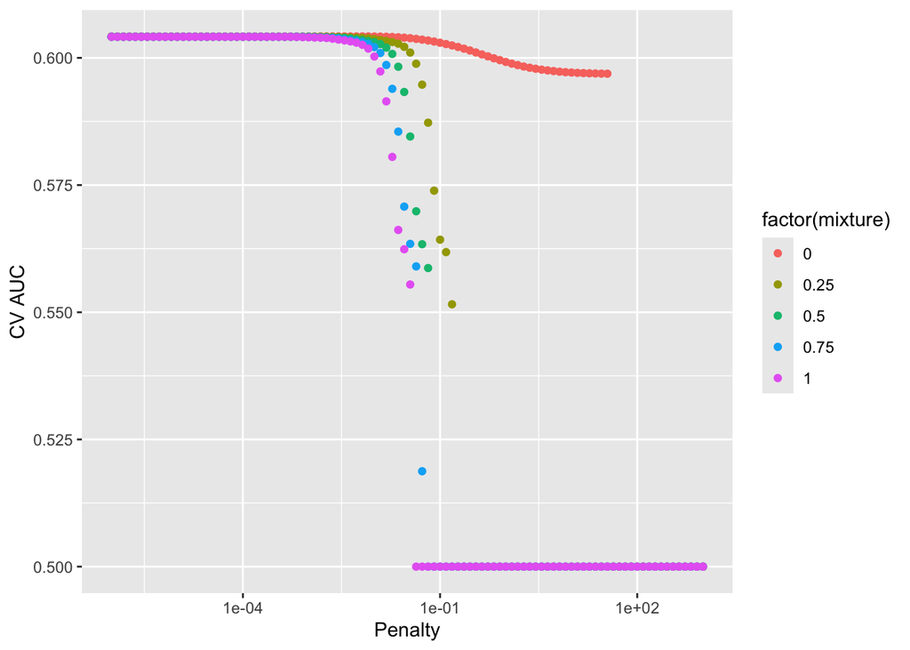

```r
# To read back the objects from the RDS files
# logit_res <- readRDS("logit_res.rds")

logit_res %>%
  collect_metrics() %>%
  print(width = Inf) %>%
  filter(.metric == "roc_auc") %>%
  ggplot(mapping = aes(x = penalty, y = mean, color = factor(mixture))) +
  geom_point() +
  labs(x = "Penalty", y = "CV AUC") +
  scale_x_log10()
```

```r
logit_res %>%
  show_best(metric = "roc_auc")
```

```
# A tibble: 5 × 8
     penalty mixture .metric .estimator  mean     n std_err .config
       <dbl>   <dbl> <chr>   <chr>      <dbl> <int>   <dbl> <chr>
1 0.00658          0 roc_auc binary     0.604     5 0.00239 Preprocessor1_Model…
2 0.000001         0 roc_auc binary     0.604     5 0.00239 Preprocessor1_Model…
3 0.00000123       0 roc_auc binary     0.604     5 0.00239 Preprocessor1_Model…
4 0.00000152       0 roc_auc binary     0.604     5 0.00239 Preprocessor1_Model…
5 0.00000187       0 roc_auc binary     0.604     5 0.00239 Preprocessor1_Model…
```

```r
#Select best model

best_logit <- logit_res %>%
  select_best(metric = "roc_auc")

best_logit
```

```
# A tibble: 1 × 3
  penalty mixture .config
    <dbl>   <dbl> <chr>
1 0.00658       0 Preprocessor1_Model043
```

```r
final_wf <- log_wf %>%
  finalize_workflow(best_logit)

final_wf
```

```
══ Workflow ════════════════════════════════════════════════════════════════════
Preprocessor: Recipe
Model: logistic_reg()

── Preprocessor ────────────────────────────────────────────────────────────────
6 Recipe Steps

• step_rm()
• step_impute_mean()
• step_impute_mode()
• step_dummy()
• step_zv()
• step_normalize()

── Model ───────────────────────────────────────────────────────────────────────
Logistic Regression Model Specification (classification)

Main Arguments:
  penalty = 0.00657933224657568
  mixture = 0

Engine-Specific Arguments:
  standardize = FALSE

Computational engine: glmnet
```

```r
# Fit the whole training set, then predict the test cases
final_logit_fit <- final_wf %>%
  last_fit(data_split)

final_logit_fit
```

```
# Resampling results
# Manual resampling
# A tibble: 1 × 6
  splits                id             .metrics .notes   .predictions .workflow
  <list>                <chr>          <list>   <list>   <list>       <list>
1 <split [36590/36591]> train/test sp… <tibble> <tibble> <tibble>     <workflow>
```

```r
final_logit_fit %>%
  collect_metrics()
```

```
# A tibble: 3 × 4
  .metric     .estimator .estimate .config
  <chr>       <chr>          <dbl> <chr>
1 accuracy    binary         0.576 Preprocessor1_Model1
2 roc_auc     binary         0.607 Preprocessor1_Model1
3 brier_class binary         0.241 Preprocessor1_Model1
```

```r
log_result <- final_logit_fit %>%
  collect_metrics() %>%
print()
```

```
# A tibble: 3 × 4
  .metric     .estimator .estimate .config
  <chr>       <chr>          <dbl> <chr>
1 accuracy    binary         0.576 Preprocessor1_Model1
2 roc_auc     binary         0.607 Preprocessor1_Model1
3 brier_class binary         0.241 Preprocessor1_Model1
```

#### Random Forest Model

```r
rf_recipe <-
  recipe(los_long ~.,
         data = cohort_other) %>%
  step_rm(subject_id, hadm_id, stay_id) %>%
  step_impute_mean(creatinine, wbc, glucose,
         bicarbonate, sodium, chloride, potassium,
         hematocrit, temperature_fahrenheit,
         respiratory_rate, non_invasive_blood_pressure_diastolic,
         non_invasive_blood_pressure_systolic, heart_rate) %>%
  step_impute_mode(marital_status) %>%
  step_naomit(los_long) %>%
  step_zv(all_numeric_predictors())

rf_recipe
```

```
── Recipe ──────────────────────────────────────────────────────────────────────
```

```
── Inputs
```

```
Number of variables by role
```

```
outcome:    1
predictor: 22
```

```
── Operations
```

```
• Variables removed: subject_id, hadm_id, stay_id
```

```
• Mean imputation for: creatinine, wbc, glucose, bicarbonate, sodium, ...
```

```
• Mode imputation for: marital_status
```

```
• Removing rows with NA values in: los_long
```

```
• Zero variance filter on: all_numeric_predictors()
```

```r
rf_mod <-
  rand_forest(
    mtry = tune(),
    trees = tune()
  ) %>%
  set_engine("ranger", importance = "impurity") %>%
  set_mode("classification")
rf_mod
```

```
Random Forest Model Specification (classification)

Main Arguments:
  mtry = tune()
  trees = tune()

Engine-Specific Arguments:
  importance = impurity

Computational engine: ranger
```

```r
rf_wf <- workflow() |>
  add_recipe(rf_recipe) |>
  add_model(rf_mod)
rf_wf
```

```
══ Workflow ════════════════════════════════════════════════════════════════════
Preprocessor: Recipe
Model: rand_forest()

── Preprocessor ────────────────────────────────────────────────────────────────
5 Recipe Steps

• step_rm()
• step_impute_mean()
• step_impute_mode()
• step_naomit()
• step_zv()

── Model ───────────────────────────────────────────────────────────────────────
Random Forest Model Specification (classification)

Main Arguments:
  mtry = tune()
  trees = tune()

Engine-Specific Arguments:
  importance = impurity

Computational engine: ranger
```

```r
rf_grid <- grid_regular(
  trees(range = c(100L, 500L)),
  mtry(range = c(1L, 5L)),
  levels = c(5, 5)
  )
```

```r
rf_res <-
  tune_grid(
    object = rf_wf,
    resamples = folds,
    grid = rf_grid,
    metrics = metric_set(roc_auc, accuracy),
    control = control_stack_grid()
  )
rf_res

# Save tuned models and other objects to an RDS file to save time
# saveRDS(rf_res, "rf_res.rds")
```

```
# A tibble: 50 × 8
    mtry trees .metric  .estimator  mean     n std_err .config
   <int> <int> <chr>    <chr>      <dbl> <int>   <dbl> <chr>
 1     1   100 accuracy binary     0.589     5 0.00415 Preprocessor1_Model01
 2     1   100 roc_auc  binary     0.627     5 0.00358 Preprocessor1_Model01
 3     1   200 accuracy binary     0.592     5 0.00209 Preprocessor1_Model02
 4     1   200 roc_auc  binary     0.630     5 0.00260 Preprocessor1_Model02
 5     1   300 accuracy binary     0.594     5 0.00106 Preprocessor1_Model03
 6     1   300 roc_auc  binary     0.636     5 0.00287 Preprocessor1_Model03
 7     1   400 accuracy binary     0.595     5 0.00377 Preprocessor1_Model04
 8     1   400 roc_auc  binary     0.635     5 0.00378 Preprocessor1_Model04
 9     1   500 accuracy binary     0.594     5 0.00298 Preprocessor1_Model05
10     1   500 roc_auc  binary     0.636     5 0.00356 Preprocessor1_Model05
# ℹ 40 more rows
```

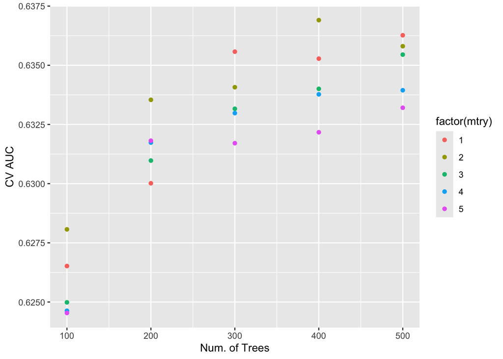

```r
# To read back the objects from the RDS files
rf_res <- readRDS("rf_res.rds")

rf_res %>%
  collect_metrics() %>%
  print(width = Inf) %>%
  filter(.metric == "roc_auc") %>%
  ggplot(mapping = aes(x = trees, y = mean, color = factor(mtry))) +
  geom_point() +
  labs(x = "Num. of Trees", y = "CV AUC")
```

```r
rf_res %>%
  show_best(metric = "roc_auc")
```

```
# A tibble: 5 × 8
   mtry trees .metric .estimator  mean     n std_err .config
  <int> <int> <chr>   <chr>      <dbl> <int>   <dbl> <chr>
1     2   400 roc_auc binary     0.637     5 0.00371 Preprocessor1_Model09
2     1   500 roc_auc binary     0.636     5 0.00356 Preprocessor1_Model05
3     2   500 roc_auc binary     0.636     5 0.00226 Preprocessor1_Model10
4     1   300 roc_auc binary     0.636     5 0.00287 Preprocessor1_Model03
5     3   500 roc_auc binary     0.635     5 0.00334 Preprocessor1_Model15
```

```r
best_rf <- rf_res %>%
  select_best(metric = "roc_auc")

best_rf
```

```
# A tibble: 1 × 3
   mtry trees .config
  <int> <int> <chr>
1     2   400 Preprocessor1_Model09
```

```r
final_wf <- rf_wf %>%
  finalize_workflow(best_rf)

final_wf
```

```
══ Workflow ════════════════════════════════════════════════════════════════════
Preprocessor: Recipe
Model: rand_forest()

── Preprocessor ────────────────────────────────────────────────────────────────
5 Recipe Steps

• step_rm()
• step_impute_mean()
• step_impute_mode()
• step_naomit()
• step_zv()

── Model ───────────────────────────────────────────────────────────────────────
Random Forest Model Specification (classification)

Main Arguments:
  mtry = 2
  trees = 400

Engine-Specific Arguments:
  importance = impurity

Computational engine: ranger
```

```r
# Fit the whole training set, then predict the test cases
final_rf_fit <-
  final_wf %>%
  last_fit(data_split)

final_rf_fit
```

```
# Resampling results
# Manual resampling
# A tibble: 1 × 6
  splits                id             .metrics .notes   .predictions .workflow
  <list>                <chr>          <list>   <list>   <list>       <list>
1 <split [36590/36591]> train/test sp… <tibble> <tibble> <tibble>     <workflow>
```

```r
final_rf_fit %>%
  collect_metrics()
```

```
# A tibble: 3 × 4
  .metric     .estimator .estimate .config
  <chr>       <chr>          <dbl> <chr>
1 accuracy    binary         0.603 Preprocessor1_Model1
2 roc_auc     binary         0.644 Preprocessor1_Model1
3 brier_class binary         0.235 Preprocessor1_Model1
```

```r
rf_result <- final_rf_fit %>%
  collect_metrics() %>%
  print()
```

```
# A tibble: 3 × 4
  .metric     .estimator .estimate .config
  <chr>       <chr>          <dbl> <chr>
1 accuracy    binary         0.603 Preprocessor1_Model1
2 roc_auc     binary         0.644 Preprocessor1_Model1
3 brier_class binary         0.235 Preprocessor1_Model1
```

#### Boosting Model

```r
# Define recipe
bt_recipe <- recipe(los_long ~ ., data = cohort_other) %>%
  step_rm(subject_id, hadm_id, stay_id) %>%
  step_impute_mean(creatinine, wbc, glucose,
         bicarbonate, sodium, chloride, potassium,
         hematocrit, temperature_fahrenheit,
         respiratory_rate, non_invasive_blood_pressure_diastolic,
         non_invasive_blood_pressure_systolic, heart_rate) %>%
  step_impute_mode(marital_status) %>%
  step_dummy(all_nominal_predictors()) %>%
  step_zv(all_numeric_predictors())
bt_recipe
```

```
── Recipe ──────────────────────────────────────────────────────────────────────
```

```
── Inputs
```

```
Number of variables by role
```

```
outcome:    1
predictor: 22
```

```
── Operations
```

```
• Variables removed: subject_id, hadm_id, stay_id
```

```
• Mean imputation for: creatinine, wbc, glucose, bicarbonate, sodium, ...
```

```
• Mode imputation for: marital_status
```

```
• Dummy variables from: all_nominal_predictors()
```

```
• Zero variance filter on: all_numeric_predictors()
```

```r
# Define model
bt_mod <- boost_tree(
  trees = 1000,
  tree_depth = tune(),
  learn_rate = tune()
) %>%
  set_engine("xgboost", importance = "weight") %>%
  set_mode("classification")

bt_mod
```

```
Boosted Tree Model Specification (classification)

Main Arguments:
  trees = 1000
  tree_depth = tune()
  learn_rate = tune()

Engine-Specific Arguments:
  importance = weight

Computational engine: xgboost
```

```r
# Define workflow
bt_wf <- workflow() %>%
  add_model(bt_mod) %>%
  add_recipe(bt_recipe)
bt_wf
```

```
══ Workflow ════════════════════════════════════════════════════════════════════
Preprocessor: Recipe
Model: boost_tree()

── Preprocessor ────────────────────────────────────────────────────────────────
5 Recipe Steps

• step_rm()
• step_impute_mean()
• step_impute_mode()
• step_dummy()
• step_zv()

── Model ───────────────────────────────────────────────────────────────────────
Boosted Tree Model Specification (classification)

Main Arguments:
  trees = 1000
  tree_depth = tune()
  learn_rate = tune()

Engine-Specific Arguments:
  importance = weight

Computational engine: xgboost
```

```r
# Define grid
bt_grid <- grid_regular(
  tree_depth(range = c(1L, 5L)),
  learn_rate(range = c(-5, 2),
             trans = log10_trans()),
  levels = c(3, 10)
)

bt_grid
```

```
# A tibble: 30 × 2
   tree_depth learn_rate
        <int>      <dbl>
 1          1  0.00001
 2          3  0.00001
 3          5  0.00001
 4          1  0.0000599
 5          3  0.0000599
 6          5  0.0000599
 7          1  0.000359
 8          3  0.000359
 9          5  0.000359
10          1  0.00215
# ℹ 20 more rows
```

```r
set.seed(203)
folds <- vfold_cv(cohort_other, v = 5)

folds

numCores <- detectCores()
clust <- makeCluster(numCores - 1)
registerDoParallel(clust)

# Tune model
bt_res <- bt_wf %>%
    tune_grid(
    resamples = folds,
    grid = bt_grid,
    metrics = metric_set(roc_auc, accuracy),
    control = control_stack_grid()
  )

bt_res

stopCluster(clust)

# Save tuned models and other objects to an RDS file to save time
# saveRDS(bt_res, "bt_res.rds")
```

```
# A tibble: 60 × 8
   tree_depth learn_rate .metric  .estimator  mean     n std_err
        <int>      <dbl> <chr>    <chr>      <dbl> <int>   <dbl>
 1          1  0.00001   accuracy binary     0.539     5 0.00232
 2          1  0.00001   roc_auc  binary     0.533     5 0.00547
 3          3  0.00001   accuracy binary     0.556     5 0.00429
 4          3  0.00001   roc_auc  binary     0.562     5 0.00270
 5          5  0.00001   accuracy binary     0.563     5 0.00227
 6          5  0.00001   roc_auc  binary     0.579     5 0.00336
 7          1  0.0000599 accuracy binary     0.538     5 0.00505
 8          1  0.0000599 roc_auc  binary     0.555     5 0.00297
 9          3  0.0000599 accuracy binary     0.556     5 0.00607
10          3  0.0000599 roc_auc  binary     0.574     5 0.00666
   .config
   <chr>
 1 Preprocessor1_Model01
 2 Preprocessor1_Model01
 3 Preprocessor1_Model02
 4 Preprocessor1_Model02
 5 Preprocessor1_Model03
 6 Preprocessor1_Model03
 7 Preprocessor1_Model04
 8 Preprocessor1_Model04
 9 Preprocessor1_Model05
10 Preprocessor1_Model05
# ℹ 50 more rows
```

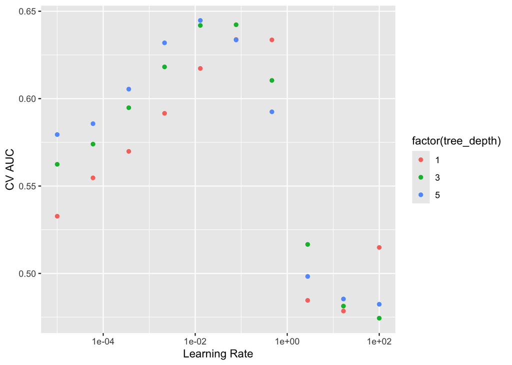

```r
# To read back the objects from the RDS files
bt_res <- readRDS("bt_res.rds")

bt_res %>%
  collect_metrics() %>%
  print(width = Inf) %>%
  filter(.metric == "roc_auc") %>%
  ggplot(mapping = aes(x = learn_rate, y = mean, color = factor(tree_depth))) +
  geom_point() +
  labs(x = "Learning Rate", y = "CV AUC") +
  scale_x_log10()
```

```r
# Collect and filter metrics
bt_res %>%
  show_best(metric = "roc_auc")
```

```
# A tibble: 5 × 8
  tree_depth learn_rate .metric .estimator  mean     n std_err .config
       <int>      <dbl> <chr>   <chr>      <dbl> <int>   <dbl> <chr>
1          5     0.0129 roc_auc binary     0.645     5 0.00421 Preprocessor1_Mo…
2          3     0.0774 roc_auc binary     0.642     5 0.00366 Preprocessor1_Mo…
3          3     0.0129 roc_auc binary     0.642     5 0.00465 Preprocessor1_Mo…
4          1     0.0774 roc_auc binary     0.634     5 0.00354 Preprocessor1_Mo…
5          1     0.464  roc_auc binary     0.634     5 0.00345 Preprocessor1_Mo…
```

```r
# Select best model
best_bt <- bt_res %>%
  select_best(metric = "roc_auc")

best_bt
```

```
# A tibble: 1 × 3
  tree_depth learn_rate .config
       <int>      <dbl> <chr>
1          5     0.0129 Preprocessor1_Model15
```

```r
# Finalize workflow
final_wf <- bt_wf %>%
  finalize_workflow(best_bt)

final_wf
```

```
══ Workflow ════════════════════════════════════════════════════════════════════
Preprocessor: Recipe
Model: boost_tree()

── Preprocessor ────────────────────────────────────────────────────────────────
5 Recipe Steps

• step_rm()
• step_impute_mean()
• step_impute_mode()
• step_dummy()
• step_zv()

── Model ───────────────────────────────────────────────────────────────────────
Boosted Tree Model Specification (classification)

Main Arguments:
  trees = 1000
  tree_depth = 5
  learn_rate = 0.0129154966501488

Engine-Specific Arguments:
  importance = weight

Computational engine: xgboost
```

```r
# Fit the whole training set, then predict the test cases
final_bt_fit <-
  final_wf %>%
  last_fit(data_split)

final_bt_fit
```

```
# Resampling results
# Manual resampling
# A tibble: 1 × 6
  splits                id             .metrics .notes   .predictions .workflow
  <list>                <chr>          <list>   <list>   <list>       <list>
1 <split [36590/36591]> train/test sp… <tibble> <tibble> <tibble>     <workflow>
```

```r
final_bt_fit %>%
  collect_metrics()
```

```
# A tibble: 3 × 4
  .metric     .estimator .estimate .config
  <chr>       <chr>          <dbl> <chr>
1 accuracy    binary         0.609 Preprocessor1_Model1
2 roc_auc     binary         0.652 Preprocessor1_Model1
3 brier_class binary         0.232 Preprocessor1_Model1
```

```r
bt_result <- final_bt_fit %>%
  collect_metrics() %>%
  print()
```

```
# A tibble: 3 × 4
  .metric     .estimator .estimate .config
  <chr>       <chr>          <dbl> <chr>
1 accuracy    binary         0.609 Preprocessor1_Model1
2 roc_auc     binary         0.652 Preprocessor1_Model1
3 brier_class binary         0.232 Preprocessor1_Model1
```

#### Model Stacking

```r
numCores <- detectCores()
clust <- makeCluster(numCores - 1)
registerDoParallel(clust)

# Stack the models
stack <- stacks() %>%
  add_candidates(logit_res) %>%
  add_candidates(rf_res) %>%
  add_candidates(bt_res) %>%
  blend_predictions(
    penalty = 10^(-5:1),
    metrics = c("roc_auc")
  ) %>%
  fit_members()

stack
stopCluster(clust)

# Save tuned models and other objects to an RDS file to save time
# saveRDS(stack, "stack.rds")
```

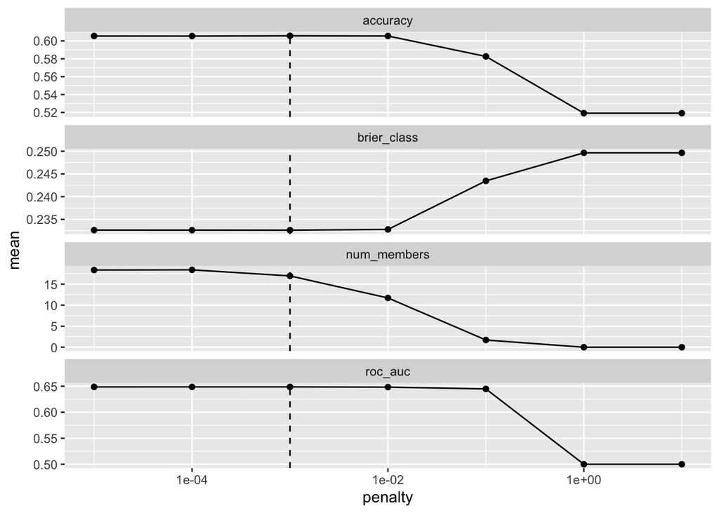

```r
# To read back the objects from the RDS files
stack <- readRDS("stack.rds")
autoplot(stack)
```

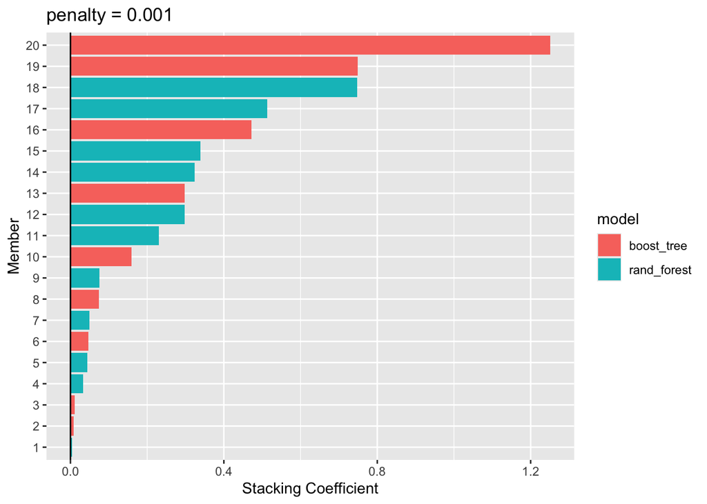

```r
autoplot(stack, type = "weights")
```

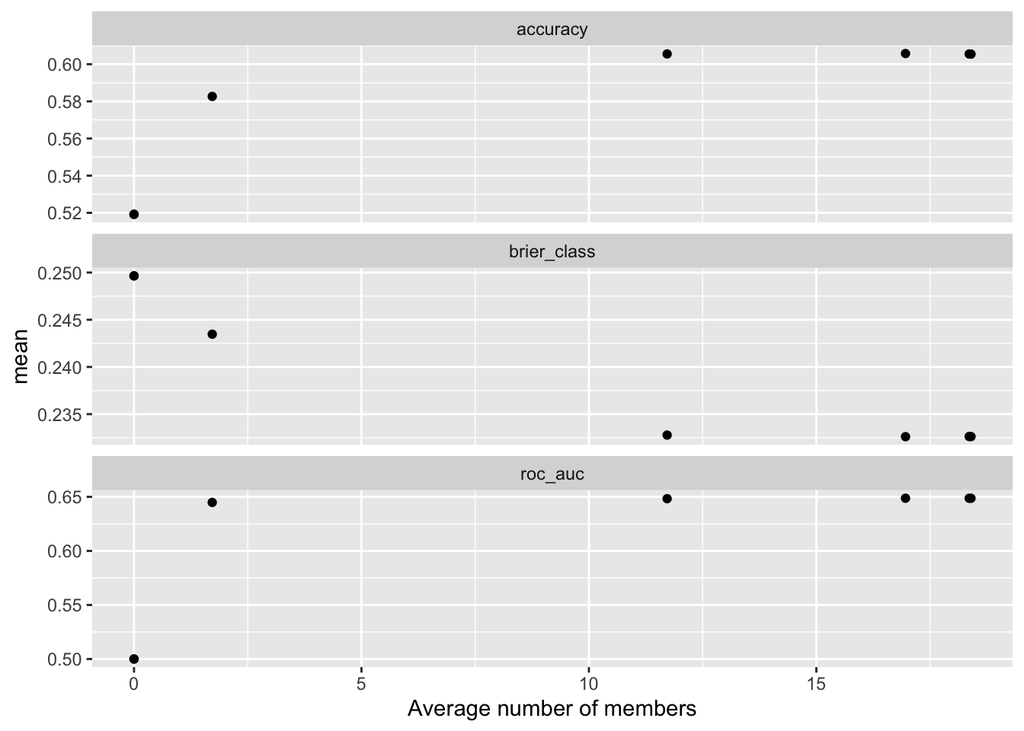

```r
autoplot(stack, type = "members")
```

## 4. Compare model classification performance on the test set. Report and interpret the results.

```r
cohort_pred <- cohort_test %>%
  bind_cols(predict(stack, ., type = "prob")) %>%
  print(width = Inf)
```

```
# A tibble: 36,591 × 25
   los_long subject_id  hadm_id  stay_id gender age_intime marital_status
   <fct>         <int>    <int>    <int> <chr>       <int> <chr>
 1 FALSE      10287015 27614346 37924967 M              68 MARRIED
 2 TRUE       12854615 29306595 38198377 M              81 MARRIED
 3 FALSE      16962213 24281725 38225138 F              60 MARRIED
 4 FALSE      17491268 21843002 31844112 M              67 MARRIED
 5 FALSE      18872730 23566640 32829081 F              66 <NA>
 6 FALSE      19994592 22001973 37963501 F              45 MARRIED
 7 FALSE      14074535 22925441 37015434 F              78 MARRIED
 8 FALSE      16886096 22262505 33076657 F              62 WIDOWED
 9 TRUE       17932276 25018638 37447763 M              52 MARRIED
10 TRUE       12489693 20379263 35263918 M              79 DIVORCED
   race     first_careunit admission_type              creatinine   wbc glucose
   <fct>    <fct>          <fct>                            <dbl> <dbl>   <dbl>
```

[output cut: 47 more lines]

```r
cohort_pred
```

```
# A tibble: 36,591 × 25
   los_long subject_id  hadm_id  stay_id gender age_intime marital_status race
   <fct>         <int>    <int>    <int> <chr>       <int> <chr>          <fct>
 1 FALSE      10287015 27614346 37924967 M              68 MARRIED        Other
 2 TRUE       12854615 29306595 38198377 M              81 MARRIED        BLACK
 3 FALSE      16962213 24281725 38225138 F              60 MARRIED        WHITE
 4 FALSE      17491268 21843002 31844112 M              67 MARRIED        WHITE
 5 FALSE      18872730 23566640 32829081 F              66 <NA>           Other
 6 FALSE      19994592 22001973 37963501 F              45 MARRIED        HISPA…
 7 FALSE      14074535 22925441 37015434 F              78 MARRIED        WHITE
 8 FALSE      16886096 22262505 33076657 F              62 WIDOWED        WHITE
 9 TRUE       17932276 25018638 37447763 M              52 MARRIED        WHITE
10 TRUE       12489693 20379263 35263918 M              79 DIVORCED       Other
# ℹ 36,581 more rows
# ℹ 17 more variables: first_careunit <fct>, admission_type <fct>,
#   creatinine <dbl>, wbc <dbl>, glucose <dbl>, chloride <dbl>,
#   hematocrit <dbl>, potassium <dbl>, bicarbonate <dbl>, sodium <dbl>,
#   temperature_fahrenheit <dbl>, respiratory_rate <dbl>,
#   non_invasive_blood_pressure_diastolic <dbl>,
#   non_invasive_blood_pressure_systolic <dbl>, heart_rate <dbl>, …
```

```r
stack_roc <- yardstick::roc_auc(
  cohort_pred,
  truth = los_long,
  contains(".pred_FALSE")
  )
stack_roc
```

```
# A tibble: 1 × 3
  .metric .estimator .estimate
  <chr>   <chr>          <dbl>
1 roc_auc binary         0.657
```

```r
label <- factor(ifelse(cohort_pred$.pred_TRUE > 0.5, "TRUE", "FALSE"),
                levels = c("FALSE", "TRUE"))
los_long_label <- factor(cohort_pred$los_long, levels = c("FALSE", "TRUE"))

acy <- accuracy_vec(truth = los_long_label, estimate = label)
print(acy)
```

```
[1] 0.612473
```

#### models performance

```r
models <- c("logit_res", "rf_res", "bt_res", "stack")

models_performance <- tibble(
  model = c("Logistic Regression", "Random Forest", "Boosting", "Stacking"),
  accuracy = c(
  log_result$.estimate[1], rf_result$.estimate[1], bt_result$.estimate[1],
  stack_roc$.estimate),
  roc_auc = c(
  log_result$.estimate[2], rf_result$.estimate[2], bt_result$.estimate[2],
  acy)
)
models_performance
```

[output not shown]

#### Interpretation

In terms of feature importance, Boosting models like XGBoost provide a way to assess the importance of each feature. Important features usually involve vital signs, lab results, and demographic information that are indicative of the patient’s health at the time of ICU admission. Feature importance can be extracted and visualized using techniques like permutation importance or SHAP (SHapley Additive exPlanations) values.

#### the most important features

```r
# Assuming `final_logit_fit` is your fitted logistic regression model
logit_fit <- extract_fit_parsnip(final_logit_fit)

# Extract the non-zero coefficients at the best lambda
best_lambda <- logit_fit$fit$lambda.min
coefs <- predict(logit_fit$fit, type = "coefficients", s = best_lambda)[,1]

# Create a data frame of features and their coefficients
feature_importance_logit <- as.data.frame(coefs, stringsAsFactors = FALSE)
feature_importance_logit <- feature_importance_logit[-1, , drop = FALSE]
names(feature_importance_logit) <- c("coefficient")
feature_importance_logit$feature <- rownames(feature_importance_logit)
feature_importance_logit <- feature_importance_logit[
  order(abs(feature_importance_logit$coefficient), decreasing = TRUE), ]

# Print the sorted feature importances
print(feature_importance_logit)
```

```
                                                                  coefficient
heart_rate                                                       4.005735e-38
admission_type_URGENT                                            3.765199e-38
respiratory_rate                                                 3.588466e-38
hematocrit                                                      -2.585242e-38
age_intime                                                       2.357144e-38
admission_type_SURGICAL.SAME.DAY.ADMISSION                      -2.243976e-38
wbc                                                              2.233858e-38
non_invasive_blood_pressure_systolic                            -2.172153e-38
first_careunit_Other                                             2.032167e-38
first_careunit_Medical.Surgical.Intensive.Care.Unit..MICU.SICU. -1.998261e-38
first_careunit_Medical.Intensive.Care.Unit..MICU.               -1.768141e-38
chloride                                                        -1.704118e-38
race_Other                                                       1.574190e-38
creatinine                                                       1.441384e-38
admission_type_OBSERVATION.ADMIT                                 1.343902e-38
marital_status_SINGLE                                           -8.427123e-39
marital_status_MARRIED                                           8.174836e-39
admission_type_Other                                            -8.025066e-39
sodium                                                          -7.516441e-39
gender_M                                                         7.483440e-39
potassium                                                        7.481876e-39
race_BLACK                                                      -7.469142e-39
temperature_fahrenheit                                           4.894935e-39
first_careunit_Surgical.Intensive.Care.Unit..SICU.               4.817505e-39
race_WHITE                                                      -4.604539e-39
bicarbonate                                                      3.571844e-39
glucose                                                          3.230164e-39
race_HISPANIC                                                   -2.176832e-39
non_invasive_blood_pressure_diastolic                            2.051076e-39
marital_status_WIDOWED                                           1.936831e-39
                                                                                                                        feature
heart_rate                                                                                                           heart_rate
admission_type_URGENT                                                                                     admission_type_URGENT
respiratory_rate                                                                                               respiratory_rate
hematocrit                                                                                                           hematocrit
age_intime                                                                                                           age_intime
admission_type_SURGICAL.SAME.DAY.ADMISSION                                           admission_type_SURGICAL.SAME.DAY.ADMISSION
wbc                                                                                                                         wbc
non_invasive_blood_pressure_systolic                                                       non_invasive_blood_pressure_systolic
first_careunit_Other                                                                                       first_careunit_Other
```

[output cut: 21 more lines]

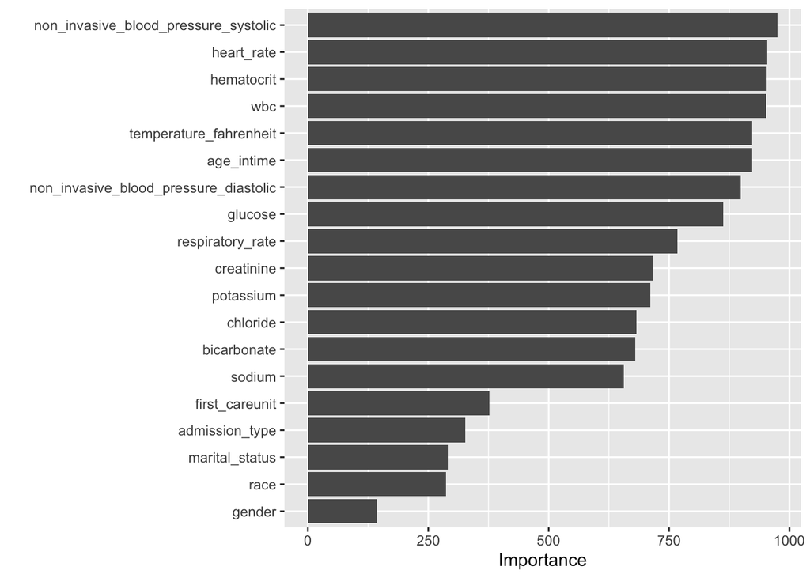

```r
# Extract the fitted random forest model
fitted_rf <- extract_fit_parsnip(final_rf_fit)

# Use vip to get feature importance
rf_importance <- vip(fitted_rf, num_features = 20)
plot(rf_importance)
```

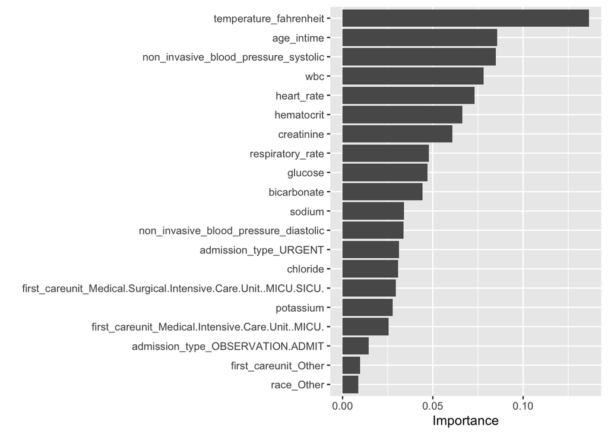

```r
# Extract the fitted boosting model
fitted_bt <- extract_fit_parsnip(final_bt_fit)

# Use vip to get feature importance
bt_importance <- vip(fitted_bt, num_features = 20)
plot(bt_importance)
```

The most important features in predicting long ICU stays are likely to be those that reflect the patient’s health status and comorbidities at the time of ICU admission. These could include vital signs like heart rate, respiratory rate, temperature, addmission type, non_invasive_blood_pressure_systolic, as well as lab results like creatinine, and glucose, etc.

#### Models Comparison

Interpretability: Logistic Regression and Random Forest models are often more interpretable than Boosting models. The logistic regression model, for example, can give insights into the odds ratio of each feature, while random forests can offer information about feature importance. Boosting models, while typically less interpretable, can be explored with tools like SHAP values to gain insights into how features affect predictions.

In conclusion, when choosing the model for predicting ICU stay length, one must balance the need for predictive power with the need for interpretability and trust in a high-stakes clinical environment. Additional validation on external datasets or in a clinical trial setting would be beneficial before deploying any of these models in a real-world scenario.